# From InterCatch to CEF age–structured data for sole 8ab

JB Lecomte

2026-10-05

## Overview

This vignette illustrates the workflow used to transform InterCatch data into age–structured CEF data for sole in ICES areas 8ab, including:  
- Importing InterCatch data and converting to CEF format.  
- Linking CEF catches and distributions via `domainBiology`.  
- Applying age allocation to strata without biological sampling.  
- Producing summary tables and diagnostic plots for quality control.

## Packages and helper functions

```r
library(icesVocab)   # ICES vocabularies (code lists)
library(icesSD)      # ICES spatial data (subdivisions, areas)
library(tidyverse)   # Data manipulation and plotting
library(here)        # Project-root–relative paths
library(glue)        # String interpolation
library(data.table)  # Efficient data manipulation (used by helper fns)

# Helper functions specific to this workflow
source(here("R/funIntercatchCEF.R"))
source( here("R/funICoutCEF.R"))
source( here("R/funMakeRelation.R"))
source( here("R/cef_add_strata.R"))
source( here("R/cef_compute_ref_numbers.R"))
source( here("R/cef_allocate_age_strata.R"))
source( here("R/sop.R"))
```

## Input paths and global settings

```r
# Base paths for input InterCatch data and raised outputs
path_to_data    <- here("WGRDBESstockCoord/personal/JB/data")
path_data_raised <- here("WGRDBESstockCoord/personal/JB/output")

# Assessment year and maximum age group used in +–grouping
data_year   <- 2024
max_agestock <- 8
```

## Export InterCatch data to CEF format

In this step, InterCatch data are read and exported to CEF format using `funICoutCEF()`.  
The function returns a list of CEF tables, including the age distribution table used later in the workflow.

```r
list_cef <- funICoutCEF(
  dat_path       = glue("{path_to_data}/"),
  years          = data_year,
  metier6        = "Fleet",
  output_format  = "to_list",
  out_path       = path_to_data,
  keep_temp_file = TRUE,
  file_prefix    = "sol_8ab"
)
```

```
#> [1] "Creating CEF from:"
#> [1] "hi.csv" "sd.csv" "si.csv"
```

## Raised catch overview and strata definition

We load the raised landings and discards overview, then standardise strata definitions using `cef_remove_strata()` and `cef_add_strata()`.  
The `seasonValue` is coerced to character to ensure consistent joins downstream.

```r
df_stock_overview_L_D_raised <- readRDS(
  here(glue("WGRDBESstockCoord/personal/JB/output/df_stock_overview_L_D_raised{data_year}.rds"))
) %>%
  cef_remove_strata() %>%
  cef_add_strata() %>%
  mutate(seasonValue = as.character(seasonValue))
```

### Link catches and distributions via `domainBiology`

We extract unique combinations of `domainBiology`, `catchCategory`, and `strata_full` that are needed to link CEF catches and distributions.  
Catch categories are harmonised (e.g. `"Dis_total"` → `"Dis"`) to match the categories used in the CEF distribution table.

```r
df_catch_domainBiology <- df_stock_overview_L_D_raised %>%
  filter(!is.na(domainBiology)) %>%
  select(
    domainBiology,
    catchCategory,
    strata_full
  ) %>%
  mutate(
    catchCategory = case_when(
      catchCategory == "Dis_total" ~ "Dis",
      catchCategory == "BMS_total" ~ "BMS",
      catchCategory == "Lan_total" ~ "Lan",
      TRUE                         ~ catchCategory
    )
  ) %>%
  distinct()
```

## CEF distributions and merging with catches

We start from the CEF distributions table, harmonise numeric values and catch categories, then link to the catch strata via `domainBiology`.  
Strata are expanded using `cef_expand_strata_full()` to ensure all derived strata fields are available.

```r
cef_distribution <- list_cef$distributions %>%
  mutate(
    value         = as.numeric(value),
    catchCategory = case_when(
      catchCategory == "DIS" ~ "Dis",
      catchCategory == "BMS" ~ "BMS",
      catchCategory == "LAN" ~ "Lan",
      TRUE                  ~ catchCategory
    )
  ) %>%
  left_join(
    df_catch_domainBiology,
    by = join_by(catchCategory, domainBiology)
  ) %>%
  mutate(
    importedOrRaised = "imported",
    Age              = distributionClass
  ) %>%
  droplevels() %>%
  cef_expand_strata_full()
```

We then pivot the distribution data to obtain age–specific numbers and weights by strata and catch category.

```r
df_canum_imported <- cef_distribution %>%
  pivot_wider(
    values_from = value,
    id_cols     = c(strata_full, distributionClass, catchCategory),
    names_from  = c(variableType, valueType),
    names_sep   = "_",
    unused_fn   = dplyr::first
  ) %>%
  cef_expand_strata_full()
```

### SOP corrections

If required, a standard operating procedure (SOP) correction is applied to the imported age distributions.  
The sourced script is expected to create an object such as `df_canum_imported_sopr` with corrected age–specific numbers and weights.

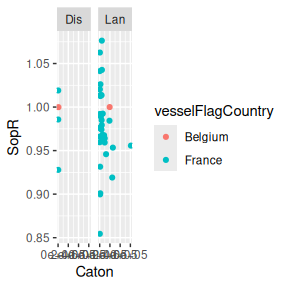

```r
###-----------------------------------------------------------------------------
### Sum Of Products (SOP) correction
###-----------------------------------------------------------------------------

### Compute SOP using sop function in fun/project folder
df_sop <-  sop(caton = df_stock_overview_L_D_raised,
               canum = df_canum_imported,
               by = c("vesselFlagCountry", "seasonValue", "year", "areaValue",
                      "fleetValue", "catchCategory"))



plot_sop <- ggplot(df_sop,
                   aes(x = Caton, y = SopR, col = vesselFlagCountry)) +
  geom_point() +
  facet_wrap(~ catchCategory)
plot_sop
```

```r
ggsave(plot = plot_sop,
       filename = glue("{path_data_raised}/plot_sop.png"),
       width = 20, height = 20, units = "cm")

### Compute SOP ratio
df_sop_ratio <- df_sop %>%
  group_by(year,catchCategory) %>%
  summarise(Caton = sum(Caton), Sop = sum(Sop))

plot_sop_ratio <- ggplot(df_sop_ratio,
                         aes(x = as.factor(year),
                             y = Sop/Caton,
                             color = catchCategory)) +
  geom_point() +
  geom_line() +
  xlab("Year")

ggsave(plot = plot_sop_ratio,
       filename = glue("{path_data_raised}/plot_sop_ratio.png"),
       width = 20, height = 20, units = "cm")

list_sop <- list(df_sop = df_sop,
                 df_sop_ratio = df_sop_ratio,
                 plot_sop = plot_sop,
                 plot_sop_ratio = plot_sop_ratio)

saveRDS(list_sop,
        file = glue("{path_data_raised}/list_sop.rds"))

# sop correction
df_canum_imported_sopr <- inner_join(df_canum_imported,
                                     df_sop) %>%
  mutate(Number_Total_SopR = Number_Total / SopR)



# After sourcing, we assume that df_canum_imported_sopr is available and
# will be used as the reference for age allocation.
```

## Identify strata with and without age sampling

We distinguish between strata with available age sampling (`df_ref_fleets`) and strata where age must be allocated (`df_allocation_fleets`).  
The vector `strata_no_age` keeps track of strata still lacking age information throughout the iterative allocation.

```r
# Reference strata: have imported age information
df_ref_fleets <- df_stock_overview_L_D_raised %>%
  filter(strata_full %in% unique(df_canum_imported$strata_full)) %>%
  droplevels()

# Strata requiring age allocation
df_allocation_fleets <- df_stock_overview_L_D_raised %>%
  filter(!(strata_full %in% unique(df_canum_imported$strata_full))) %>%
  droplevels()

# Strata identifiers without age information
strata_no_age <- df_allocation_fleets %>%
  select(strata_full)

# Reference CEF age distributions (after SOP corrections)
df_canum_for_allocation <- df_canum_imported_sopr
```

## Age allocation rules and iterative allocation

We define a hierarchy of strata–grouping rules to allocate age compositions to unsampled strata.  
The allocation proceeds from the most specific grouping to the most aggregated, updating the list of unsatisfied strata after each step.

```r
allocation_specs <- list(
  list(
    group_strata  = "strata_c_q_g",
    join_by_cols  = c("strata_c_q_g", "catchCategory"),
    source_name   = "strata_c_q_g"
  ),
  list(
    group_strata  = "strata_q_g",
    join_by_cols  = c("strata_q_g", "catchCategory"),
    source_name   = "strata_q_g"
  ),
  list(
    group_strata  = "strata_q_sg",
    join_by_cols  = c("strata_q_sg", "catchCategory"),
    source_name   = "strata_q_sg"
  ),
  list(
    group_strata  = "strata_g",
    join_by_cols  = c("strata_g", "catchCategory"),
    source_name   = "strata_g"
  ),
  list(
    group_strata  = "strata_sg",
    join_by_cols  = c("strata_sg", "catchCategory"),
    source_name   = "strata_sg"
  ),
  list(
    group_strata  = "strata_c_q",
    join_by_cols  = c("strata_c_q", "catchCategory"),
    source_name   = "strata_c_q",
    extra_filter  = quote(gear == "MIS") # optional extra filter if used in helper
  ),
  list(
    group_strata  = "strata_c",
    join_by_cols  = c("strata_c", "catchCategory"),
    source_name   = "strata_c"
  )
)
```

We then loop over the specification list and apply `cef_allocate_strata()` at each level.  
After each allocation step, we update `strata_no_age` so that remaining strata are passed to the next, more aggregated, rule.

```r
allocated_list <- list()

for (i in seq_along(allocation_specs)) {
  spec <- allocation_specs[[i]]

  allocated_list[[i]] <- cef_allocate_strata(
    df_allocation_fleets    = df_allocation_fleets,
    df_canum_for_allocation = df_canum_for_allocation,
    strata_no_age           = strata_no_age,
    number_col              = "Number_Total_SopR",
    group_strata            = spec$group_strata,
    join_by_cols            = spec$join_by_cols,
    source_name             = spec$source_name
  )

  # Remove strata that have just been allocated from the remaining pool
  strata_no_age <- strata_no_age %>%
    filter(!(strata_full %in% levels(allocated_list[[i]]$strata_full))) %>%
    droplevels()
}
```

## Combine imported and allocated CEF age data

We bind all allocated strata, clean up temporary variables, and recombine them with the original imported age data.  
Weights and total catch columns are standardised, and strata fields are flattened for later aggregation and export.

```r
df_canum_allocated <- bind_rows(allocated_list) %>%
  cef_remove_strata() %>%
  rename(
    Caton   = Catchkg,
    weights = weights_ref
  ) %>%
  select(
    -any_of(c(
      "DiscardsImportedOrRaised",
      "raised_landings",
      "numbers_ref_tot",
      "weca_tot",
      "SoP"
    ))
  ) %>%
  mutate(seasonValue = as.character(seasonValue))

df_canum_for_allocation <- df_canum_for_allocation %>%
  cef_remove_strata()

df_canum <- bind_rows(
  df_canum_for_allocation,
  df_canum_allocated
) %>%
  cef_remove_strata()

saveRDS(
  df_canum,
  file = glue("{path_data_raised}/df_canum_all_age_{data_year}.rds")
)
```

## Age–plus grouping

For assessment purposes we aggregate all ages at or above `max_agestock` into a single plus group.  
Numbers are summed by `strata_full`, `Age`, and `catchCategory`.

```r
df_canum_ageplus <- df_canum %>%
  mutate(
    Age = ifelse(
      as.numeric(Age) >= as.numeric(max_agestock),
      as.character(max_agestock),
      Age
    )
  ) %>%
  group_by(strata_full, Age, catchCategory) %>%
  mutate(Number_Total = sum(Number_Total)) %>%
  distinct()

saveRDS(
  df_canum_ageplus,
  file = glue("{path_data_raised}/df_canum_ageplus_{data_year}.rds")
)
```

## Mean weights by strata and age

We compute mean weights using numbers as weights at different aggregation levels:  
- By full strata, catch category, and age.  
- By catch category and age (with plus group).  
- By age only (with plus group).

```r
df_weights_strata_CatchCat_Age <- df_canum %>%
  group_by(strata_full, catchCategory, Age) %>%
  mutate(mean_weights = sum(weights * numbers) / sum(numbers))

saveRDS(
  df_weights_strata_CatchCat_Age,
  file = glue("{path_data_raised}/df_weights_strata_{data_year}.rds")
)
```

Mean weights by catch category and age, including a plus group:

```r
df_weights_CatchCat_Age <- df_canum %>%
  filter(as.numeric(Age) < as.numeric(max_agestock)) %>%
  group_by(catchCategory, Age) %>%
  mutate(
    mean_weights = sum(weights * numbers) / sum(numbers),
    Age          = as.character(Age)
  )

df_weights_CatchCat_AgePlus <- df_canum %>%
  filter(as.numeric(Age) >= as.numeric(max_agestock)) %>%
  group_by(catchCategory) %>%
  mutate(
    mean_weights = sum(weights * numbers) / sum(numbers),
    Age          = as.character(max_agestock)
  )

df_weights_CatchCat_Age <- bind_rows(
  df_weights_CatchCat_Age,
  df_weights_CatchCat_AgePlus
)

saveRDS(
  df_weights_CatchCat_Age,
  file = glue("{path_data_raised}/df_weights_CatchCat_Age_{data_year}.rds")
)
```

Mean weights by age only (including plus group):

```r
df_weights_Catch_Age <- df_canum %>%
  filter(as.numeric(Age) < as.numeric(max_agestock)) %>%
  group_by(Age) %>%
  mutate(
    mean_weights = sum(weights * numbers) / sum(numbers),
    Age          = as.character(Age)
  )

df_weights_Catch_AgePlus <- df_canum %>%
  filter(as.numeric(Age) >= as.numeric(max_agestock)) %>%
  mutate(
    mean_weights = sum(weights * numbers) / sum(numbers),
    Age          = as.character(max_agestock)
  )

df_weights_Catch_Age <- bind_rows(
  df_weights_Catch_Age,
  df_weights_Catch_AgePlus
)

saveRDS(
  df_weights_Catch_Age,
  file = glue("{path_data_raised}/df_weights_Catch_Age_{data_year}.rds")
)
```

## Summary tables

We produce summaries by year, flag state, fleet, age, season, and catch category, for both the original and plus–grouped datasets.  
These are useful for quick diagnostics and comparison with other sources.

```r
dfs_canum <- df_canum %>%
  group_by(
    year,
    vesselFlagCountry,
    fleetValue,
    Age,
    seasonValue,
    catchCategory
  ) %>%
  summarise(
    numbers = sum(numbers, na.rm = TRUE),
    .groups = "drop"
  )

dfs_canum_ageplus <- df_canum_ageplus %>%
  group_by(
    year,
    vesselFlagCountry,
    fleetValue,
    Age,
    seasonValue,
    catchCategory
  ) %>%
  summarise(
    numbers = sum(numbers, na.rm = TRUE),
    .groups = "drop"
  )

dfs_canum_ageplus_allocation <- df_canum_ageplus %>%
  group_by(year, Source) %>%
  summarise(
    numbers = sum(numbers, na.rm = TRUE),
    .groups = "drop"
  ) %>%
  group_by(year) %>%
  mutate(numbers_prop = numbers / sum(numbers))
```

## Diagnostic plots: allocation by fleet and catch category

We summarise allocated numbers by year, fleet, catch category, and allocation source, then create a diagnostic plot to inspect the contribution of each allocation level.

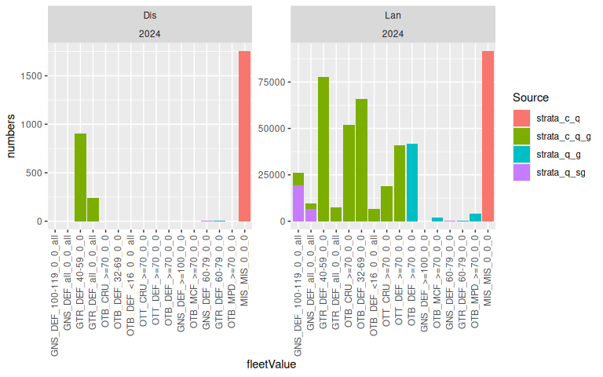

```r
dfs_canum_allocated <- df_canum_allocated %>%
  group_by(year, fleetValue, catchCategory, Source) %>%
  summarise(
    numbers = sum(numbers),
    .groups = "drop"
  )

plot_canum_allocated <- ggplot(
  dfs_canum_allocated,
  aes(fleetValue, numbers, fill = Source)
) +
  geom_col() +
  facet_wrap(catchCategory ~ year, scales = "free_y") +
  theme(
    axis.text.x = element_text(
      angle  = 90,
      hjust  = 1,
      vjust  = 0.4
    )
  )

plot_canum_allocated
```

```r
saveRDS(
  plot_canum_allocated,
  file = glue("{path_data_raised}/plot_canum_allocated.rds")
)

saveRDS(
  dfs_canum_allocated,
  file = glue("{path_data_raised}/dfs_canum_allocated.rds")
)
```

## Comparison with InterCatch age allocation

Finally, we compare the CEF–based allocation with the age allocation as produced in InterCatch.  
The script `load_IC_age_allocated_2024.R` create a comparison table `dfs_canum_allocated_comp`.

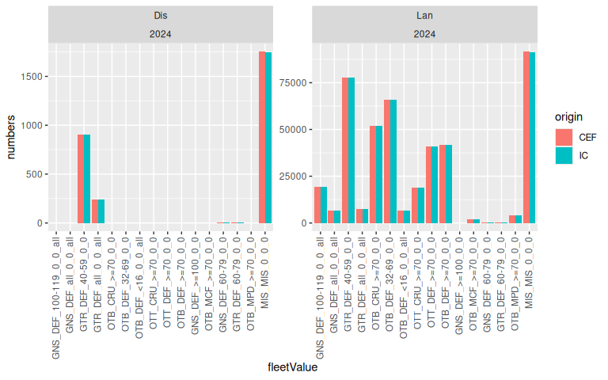

```r
source(here("WGRDBESstockCoord/personal/JB/load_IC_age_allocated_2024.R"))

plot_canum_allocated_comp <- ggplot(
  dfs_canum_allocated_comp,
  aes(fleetValue, numbers, fill = origin)
) +
  geom_col(position = position_dodge()) +
  facet_wrap(catchCategory ~ year, scales = "free_y") +
  theme(
    axis.text.x = element_text(
      angle  = 90,
      hjust  = 1,
      vjust  = 0.4
    )
  )

plot_canum_allocated_comp
```